# Avance de informe

# Salud mental en Chile

## Introducción

La salud mental en Chile es un problema que afecta a una parte importante de la población mundial, y particularmente a Chile. La OMS ubica a Chile entre los países más carga de morbilidad por enfermedades psiquiátricas en el mundo, con un 23,2% (cita SciELO 2016).

El aumento sostenido en el consumo de medicamentos antidepresivos es un fenómeno global que preocupa por los efectos adversos asociados a estos. En la segunda encuesta sobre los efectos del COVID-19 en el consumo de alcohol y otras drogas en Chile, dada a conocer por el Director Nacional de SENDA en junio de este año, se registró un 53 por ciento más de ingesta de medicamentos antidepresivos sin prescripción de un especialista.

El objetivo de este informe es describir brevemente la situación de la salud mental en Chile, a través de información gráfica y explicativa, para luego concluir en relación a los datos presentados.

## Presentación de los datos

En este informe se ha utilizado información pública obtenida a través de archivos separados por coma, disponibles en los tableros del DEIS dispuestos por el Ministerio de Salud de Chile a través de su sitio web. Se han descargado y utilizado 2 archivos separados por coma desde el tablero Reportería Programa Salud Mental 2014-2021.

Para el análisis, se ha utilizado el software estadístico R, junto con los paquetes incluidos en la librería tidyverse para la trasposición de las tablas originales y la construcción de gráficos.

## Exploración de datos

En primer lugar, la base de datos que contiene la cantidad de atenciones por sexo nos muestra que la mayor cantidad de consultas en el área de salud mental es realizada por mujeres.

A continuación, presentamos un gráfico de cantidad de atenciones diferenciadas por sexo.

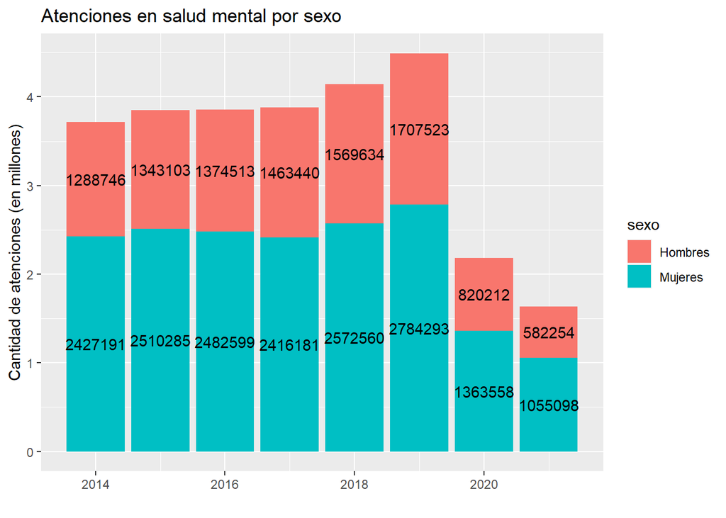

Se observa que, año a año, la cantidad de atenciones en mujeres es al menos un 60% más que en hombres. Por otra parte, se observa que hay un aumento sostenido a medida que pasan los años en la cantidad total de atenciones hasta el año 2019.

La pandemia en Chile ha generado que una parte importante de las consultas médicas queden relegadas a un segundo plano, puesto que la prioridad médica se ha otorgado a pacientes con COVID o patologías derivadas de este virus.

En el siguiente gráfico de puntos, podemos ver este efecto de manera más evidente.

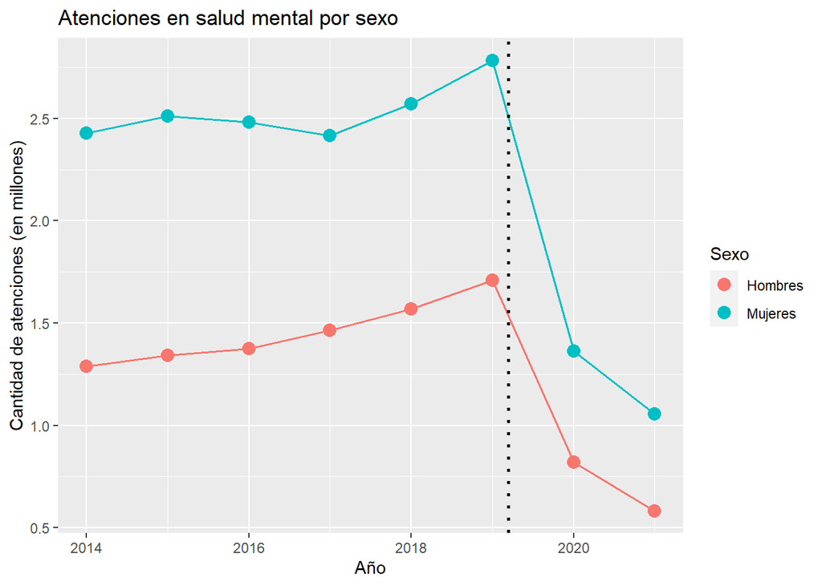

La línea punteada del gráfico nos indica que a partir de comienzos del año 2020, se inicia una abrupta caida en la cantidad de atenciones en salud mental. Esto es posible explicarse por el hecho de que la gran mayoría de centros de atención de salud primaria (CESFAM, COSAM, hospitales, etc.) suspendieron sus atenciones en esta especialidad. Por otra parte, podemos notar que las mujeres se han visto más afectadas con esta baja, ya que dicho grupo son quienes reciben más atenciones.

Por último, podemos analizar la cantidad de atenciones diferenciando por rango etario, a través del siguiente gráfico.

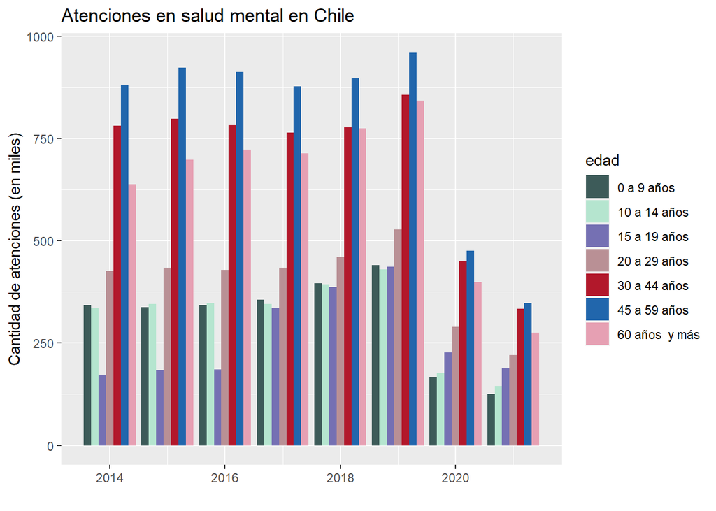

Se observa que hay 2 grupos etarios que presentan un evidente y sostenido aumento de atenciones entre 2014 y fin de 2019. Estos grupos son: 15 a 19 años y 60 años y más. Este hallazgo nos permite realizar importantes preguntas en relación a causas potenciales que pueden haber generado este aumento en adolescentes y adultos mayores.